# Unit 3 - Coding in R

Jim Flynn

September 9, 2026

## Coding in R

- **Today we will go over a series of important skills in R**
  - Loading data
  - Storing objects in R
  - Data wrangling (tidyverse)
  - Loops
  - Summary stats tables

## How to engage in this lecture

- **We are going to cover A LOT of ground this lecture**
  - The best thing you can do is just pay attention
  - There will be interactive sections where you will try to code what you’ve seen
  - Code/slides for this lecture will be available online so no need to take notes
  - You should use these slides as a coding guidebook

## Before we start…

- Coding can be incredibly frustrating
- You will often get stuck
- The more you embrace being stuck and working your way through, the better you will get
- *Stuckness shouldn’t be avoided. It’s the psychic predecessor of all real understanding. An egoless acceptance of stuckness is a key to an understanding of all Quality, in mechanical work as in other endeavors. It’s this understanding of Quality as revealed by stuckness which so often makes self-taught mechanics so superior to institute-trained men who have learned how to handle everything except a new situation.* - Robert Pirsig, ZATAOMM

## LFG - loading data

```r
#when we have a file already in Rdata format
load("mort_2021.RData")
```

```r
#slightly more complicated is RDS format
#we need to store this as an object
mort_2021 <- readRDS("mort_2021.rds")
```

## Sidebar - what does it mean to store something as an ‘object’

- R allows have to have multiple datasets open at a time
- They each get stored as ‘objects’
- We can see each of these in our global environment
- This is a **HUGE** advantage over STATA, which can only have one dataset at a time
- We can also store scalars, lists, vectors and other values, which is useful for automating code

## What if we have a STATA dataset? Excel? CSV?

```r
#this is the command for STATA data
mort_2021 <- haven::read_dta("mort_2021.dta")
```

```r
#excel - this requires the readxl package
#install.packages("readxl")
library(readxl)
mort_2021 <- read_excel("mort_2021.xlsx", sheet=1,col_names=TRUE)
```

```r
#csv - easy
mort_2021 <- read.csv("mort_2021.csv")
```

- There are tons of other ways to load data in R
- Typically, a little googling (and maybe some cursing) will get you there

## Ok, we have our data loaded! What now?

- Let’s learn some basic skills for working with and **cleaning** data
  - Explore data
  - Create variables
  - Useful functions
  - Sort data
  - Filter data
  - Summarize data
  - Merge datasets

## Most of our data-wrangling will use the tidyverse package

- Get ready to see %>% a lot
- Basically means “hold on I’m not done”

## First, let’s take a look at our data

```r
mort_2021 %>% glimpse()
```

```
## Rows: 347,286
## Columns: 16
## $ X        <int> 1, 2, 3, 4, 5, 6, 7, 8, 9, 10, 11, 12, 13, 14, 15, 16, 17, 18…
## $ restatus <int> 1, 1, 1, 1, 1, 1, 1, 1, 1, 1, 2, 2, 1, 2, 1, 1, 1, 2, 1, 2, 1…
## $ educ2003 <int> 3, 8, 4, 3, 4, 3, 3, 3, 4, 3, 1, 6, 6, 4, 3, 5, 3, 8, 5, 5, 5…
## $ monthdth <int> 1, 1, 1, 1, 1, 1, 1, 1, 1, 1, 1, 1, 1, 1, 1, 1, 1, 1, 1, 1, 1…
## $ sex      <chr> "M", "M", "M", "F", "M", "M", "M", "F", "F", "M", "F", "F", "…
## $ age      <int> 1061, 1079, 1089, 1070, 1076, 1058, 1058, 1069, 1094, 1064, 1…
## $ marstat  <chr> "D", "M", "W", "M", "M", "M", "D", "M", "W", "M", "W", "M", "…
## $ weekday  <int> 5, 4, 1, 6, 1, 3, 4, 6, 7, 2, 3, 6, 7, 5, 7, 3, 7, 4, 1, 1, 3…
## $ year     <int> 2021, 2021, 2021, 2021, 2021, 2021, 2021, 2021, 2021, 2021, 2…
## $ mandeath <int> 7, 7, 7, 7, 7, 7, 7, 7, 7, 7, 7, 7, 7, 7, 7, 7, 7, 7, 7, 7, 7…
## $ autopsy  <chr> "N", "N", "N", "N", "N", "N", "N", "N", "N", "N", "N", "N", "…
## $ ucr358   <int> 75, 194, 54, 233, 88, 211, 159, 194, 327, 93, 54, 104, 228, 3…
## $ hispanic <int> 100, 100, 100, 100, 100, 100, 100, 100, 100, 100, 100, 100, 1…
## $ race40   <int> 1, 1, 1, 3, 1, 1, 1, 1, 3, 1, 8, 1, 1, 1, 3, 1, 1, 1, 1, 1, 1…
## $ occptnr  <int> 18, 8, 24, 1, 21, 21, 21, 2, 5, 19, 26, 10, 10, 20, 1, 17, 13…
## $ uniform  <dbl> 0.094957317, 0.042225121, 0.078914933, 0.041610897, 0.0263331…
```

## Need to create variables that make more sense

- To do this, we will often use the ifelse() function

```r
mort_2021 <- mort_2021 %>%
  mutate(female = ifelse(sex == "F", 1, 0))
```

- Let’s take a look at the data

```r
table(mort_2021$female)
```

```
##
##      0      1
## 184823 162463
```

- You may prefer to use case_when()

## Let’s clean some of these other variables using the data dictionary

```r
mort_2021 <- mort_2021 %>%
  mutate(
    years_ed = case_when(
      educ2003 == 1 ~ 8,
      educ2003 == 2 ~ 10,
      educ2003 == 3 ~ 12,
      educ2003 == 4 ~ 13,
      educ2003 == 5 ~ 14,
      educ2003 == 6 ~ 16,
      educ2003 == 7 ~ 18,
      educ2003 == 8 ~ 21,
      TRUE ~ NA_real_
    ),
    age_years = case_when(
      age == 1999 ~ NA_real_,
      age < 2000  ~ as.numeric(age - 1000),
      TRUE        ~ 0
    ),
    marital_status = case_when(
      marstat == "D" ~ "Divorced",
      marstat == "M" ~ "Married",
      marstat == "S" ~ "Single",
      marstat == "U" ~ "Unknown",
      TRUE           ~ "Widowed"
    ),
    manner_of_death = case_when(
      mandeath == 1 ~ "Accident",
      mandeath == 2 ~ "Suicide",
      mandeath == 3 ~ "Homicide",
      mandeath == 7 ~ "Natural",
      TRUE          ~ "Unknown"
    ),
    hispanic_eth = case_when(
      hispanic >= 200 & hispanic <= 299 ~ 1,
      hispanic > 900                    ~ NA_real_,
      TRUE                               ~ 0
    ),
    race = case_when(
      race40 == 1                     ~ "White",
      race40 == 2                     ~ "Black",
      race40 == 3                     ~ "AIAN",
      race40 >= 4 & race40 <= 14      ~ "AAPI",
      TRUE                             ~ "Multiple Races"
    )
  )
```

## Filtering data

- Let’s say we want a dataset of just:
  - Women
  - With a college degree
  - Who died in August
- We will use filter()

```r
mort_wcda <- mort_2021 %>%
  filter(female == 1 & years_ed >= 16 & monthdth == 8)
```

## Filtering Data - cont’d

Now let’s look at our new dataset

```r
head(mort_wcda)
```

```
##      X restatus educ2003 monthdth sex  age marstat weekday year mandeath
## 1  230        1        7        8   F 1079       M       7 2021        1
## 2  335        1        6        8   F 1038       S       7 2021        1
## 3 4254        1        6        8   F 1084       M       1 2021        7
## 4 4299        2        6        8   F 1045       S       1 2021        7
## 5 4345        1        6        8   F 1069       S       4 2021        7
## 6 4354        1        7        8   F 1074       D       3 2021        7
##   autopsy ucr358 hispanic race40 occptnr    uniform female years_ed age_years
## 1       N    267      100      1       1 0.07388825      1       18        79
## 2       Y    420      100      1      11 0.06655851      1       16        38
## 3       U    194      100      1       8 0.09759705      1       16        84
## 4       N    178      100      1      10 0.08972025      1       16        45
## 5       N     81      100      1      17 0.02295228      1       16        69
## 6       N     54      100      1       8 0.06653673      1       18        74
##   marital_status manner_of_death hispanic_eth  race
## 1        Married        Accident            0 White
## 2         Single        Accident            0 White
## 3        Married         Natural            0 White
## 4         Single         Natural            0 White
## 5         Single         Natural            0 White
## 6       Divorced         Natural            0 White
```

## Summarizing our data

```r
mort_2021 %>%
  filter(is.na(years_ed)==FALSE) %>%
  summarise(avg_ed = mean(years_ed))
```

```
##     avg_ed
## 1 12.61305
```

- This is nice, but not all that informative

## Summarizing - cont’d

- Let’s split the data by gender first

```r
mort_2021 %>%
  group_by(sex) %>%
  filter(is.na(years_ed)==FALSE) %>%
  summarise(avg_ed = mean(years_ed))
```

```
## # A tibble: 2 × 2
##   sex   avg_ed
##   <chr>  <dbl>
## 1 F       12.5
## 2 M       12.7
```

## Let’s look at age at death by race

```r
mort_2021 %>%
  group_by(race) %>%
  filter(is.na(age_years)==FALSE) %>%
  summarise(avg_age = mean(age_years))
```

```
## # A tibble: 5 × 2
##   race           avg_age
##   <chr>            <dbl>
## 1 AAPI              73.2
## 2 AIAN              60.2
## 3 Black             65.0
## 4 Multiple Races    59.0
## 5 White             73.4
```

## Selecting specific variables

- Let’s say we only want age, sex, years_ed, and race
- We will also keep X which is just a count of the observations

```r
mort_asyr <- mort_2021 %>%
  select(age_years,sex,years_ed,race,X)
head(mort_asyr)
```

```
##   age_years sex years_ed  race X
## 1        61   M       12 White 1
## 2        79   M       21 White 2
## 3        89   M       13 White 3
## 4        70   F       12  AIAN 4
## 5        76   M       13 White 5
## 6        58   M       12 White 6
```

## Renaming columns

- If we don’t like the names of variables, we can rename them

```r
mort_2021 <- mort_2021 %>%
  rename(month_of_death = monthdth)
head(mort_2021)
```

```
##   X restatus educ2003 month_of_death sex  age marstat weekday year mandeath
## 1 1        1        3              1   M 1061       D       5 2021        7
## 2 2        1        8              1   M 1079       M       4 2021        7
## 3 3        1        4              1   M 1089       W       1 2021        7
## 4 4        1        3              1   F 1070       M       6 2021        7
## 5 5        1        4              1   M 1076       M       1 2021        7
## 6 6        1        3              1   M 1058       M       3 2021        7
##   autopsy ucr358 hispanic race40 occptnr    uniform female years_ed age_years
## 1       N     75      100      1      18 0.09495732      0       12        61
## 2       N    194      100      1       8 0.04222512      0       21        79
## 3       N     54      100      1      24 0.07891493      0       13        89
## 4       N    233      100      3       1 0.04161090      1       12        70
## 5       N     88      100      1      21 0.02633312      0       13        76
## 6       N    211      100      1      21 0.09570616      0       12        58
##   marital_status manner_of_death hispanic_eth  race
## 1       Divorced         Natural            0 White
## 2        Married         Natural            0 White
## 3        Widowed         Natural            0 White
## 4        Married         Natural            0  AIAN
## 5        Married         Natural            0 White
## 6        Married         Natural            0 White
```

## Merging datasets

- We will *often* need to merge multiple datasets on a particular variable or set of variables
- First, let’s create another subset, again including X

```r
mort_mm <- mort_2021 %>%
  select(marital_status,manner_of_death,X)
```

## Merging cont’d

- Now we can merge mort_asyr and mort_mm on X

```r
mort_asyrmm <- merge(mort_asyr,mort_mm,by='X')
  head(mort_asyrmm)
```

```
##   X age_years sex years_ed  race marital_status manner_of_death
## 1 1        61   M       12 White       Divorced         Natural
## 2 2        79   M       21 White        Married         Natural
## 3 3        89   M       13 White        Widowed         Natural
## 4 4        70   F       12  AIAN        Married         Natural
## 5 5        76   M       13 White        Married         Natural
## 6 6        58   M       12 White        Married         Natural
```

## Loops

- Loops are another useful coding tool
- They allow us to perform the same basic operation over and over with minor tweaks

```r
for (num in 1:10) {
  print(num)
}
```

```
## [1] 1
## [1] 2
## [1] 3
## [1] 4
## [1] 5
## [1] 6
## [1] 7
## [1] 8
## [1] 9
## [1] 10
```

## Loops with data

- There are many ways this can be helpful
- Let’s say we want to know the correlation between age and education, for each value of marital status

```r
marital_statuses <- c("Divorced","Married","Single","Widowed")

for(stat in marital_statuses) {
  print(stat)
  mort_temp <- mort_2021 %>% filter(marital_status == stat & is.na(age_years)==FALSE & is.na(years_ed)==FALSE)
print(cor(mort_temp$age_years,mort_temp$years_ed))
}
```

```
## [1] "Divorced"
## [1] 0.04681073
## [1] "Married"
## [1] 0.06532965
## [1] "Single"
## [1] 0.2869007
## [1] "Widowed"
## [1] 0.01391299
```

## Class exercises

- Everyone load up “brfss_21_class_data.dta”

```r
brfss_21 <- haven::read_dta("brfss_21_class_data.dta")
```

## Question 1

- Who can tell me which marital status in this data (married, divorced, widowed, single) is most common?

## Question 1 - hint

- try the table(dataset$varname) function

## Question 1 - answer

```r
table(brfss_21$marital_status)
```

```
##
##        . Divorced  Married   Single  Widowed
##        1    43533   170578    55048    32171
```

## Question 2

- BRFSS truncates the age variable so that all respondents above a certain age are reported as having the cutoff age
  - What’s the cutoff age?

## Question 2 - hint

- Try max(dataset$varname)

## Question 2 - answer

```r
max(brfss_21$age_years)
```

```
## [1] 80
```

## Question 2 - driving the point home

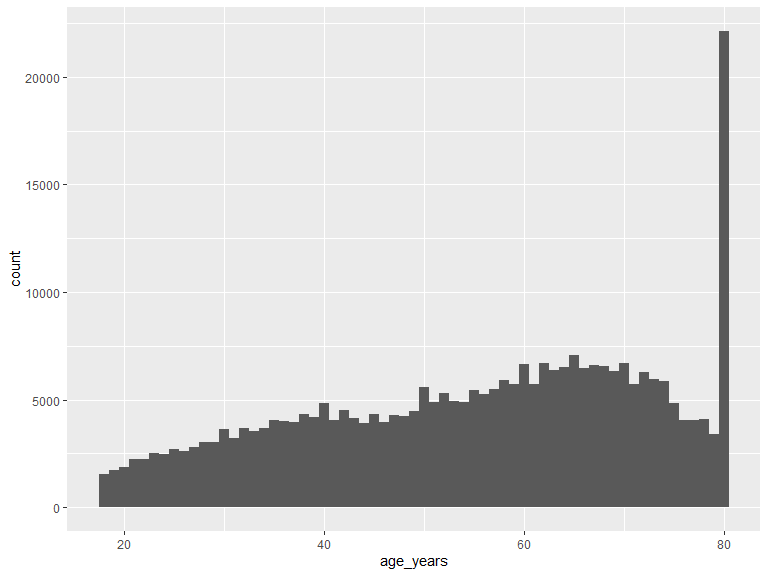

```r
ggplot(brfss_21, aes(x=age_years)) +
  geom_histogram(binwidth = 1)
```

## Question 3 - expert level

- general_health is coded as 1-5 where patients are asked to rate their overall health
  - Does a “1” mean good health or bad health?

## Question 3 - hint

- can you summarize general_health by another variable to get to the bottom of this?

## Question 3 - answer

```r
brfss_21 %>% group_by(general_health) %>%
  summarise(pct_diabetic = mean(diabetes),
            pct_exercised = mean(exer_last_30),
            avg_age = mean(age_years))
```

```
## # A tibble: 5 × 4
##   general_health pct_diabetic pct_exercised avg_age
##            <dbl>        <dbl>         <dbl>   <dbl>
## 1              1       0.0292         0.886    50.0
## 2              2       0.0745         0.849    54.0
## 3              3       0.169          0.734    56.3
## 4              4       0.298          0.570    59.8
## 5              5       0.358          0.388    62.3
```

## Summary stats tables

- Summary stats tables are a great way to show the end user ‘what the data look like’
- Lots of great packages in R, we will use the “vtable” package and the sumtable() function

## sumtable()

```r
sumtable(mort_2021)
```

Summary Statistics

| Variable | N | Mean | Std. Dev. | Min | Pctl. 25 | Pctl. 75 | Max |
| --- | --- | --- | --- | --- | --- | --- | --- |
| X | 347286 | 173644 | 100253 | 1 | 86822 | 260465 | 347286 |
| restatus | 347286 | 1.2 | 0.51 | 1 | 1 | 1 | 4 |
| educ2003 | 347286 | 3.7 | 1.8 | 1 | 3 | 5 | 9 |
| month_of_death | 347286 | 6.5 | 3.6 | 1 | 3 | 10 | 12 |
| sex | 347286 |  |  |  |  |  |  |
| … F | 162463 | 47% |  |  |  |  |  |
| … M | 184823 | 53% |  |  |  |  |  |
| age | 347286 | 1088 | 240 | 1001 | 1063 | 1086 | 9999 |
| marstat | 347286 |  |  |  |  |  |  |
| … D | 60339 | 17% |  |  |  |  |  |
| … M | 127870 | 37% |  |  |  |  |  |
| … S | 53124 | 15% |  |  |  |  |  |
| … U | 3000 | 1% |  |  |  |  |  |
| … W | 102953 | 30% |  |  |  |  |  |
| weekday | 347286 | 4 | 2 | 1 | 2 | 6 | 9 |
| year | 347286 | 2021 | 0 | 2021 | 2021 | 2021 | 2021 |
| mandeath | 318820 | 6.4 | 1.7 | 1 | 7 | 7 | 7 |
| autopsy | 347286 |  |  |  |  |  |  |
| … N | 310045 | 89% |  |  |  |  |  |
| … U | 10112 | 3% |  |  |  |  |  |
| … Y | 27129 | 8% |  |  |  |  |  |
| ucr358 | 347286 | 199 | 105 | 6 | 104 | 243 | 456 |
| hispanic | 347286 | 114 | 59 | 100 | 100 | 100 | 998 |
| race40 | 347286 | 1.4 | 1.8 | 1 | 1 | 1 | 39 |
| occptnr | 342217 | 16 | 7.8 | 1 | 10 | 22 | 26 |
| uniform | 347286 | 0.05 | 0.029 | 0.00000013 | 0.025 | 0.075 | 0.1 |
| female | 347286 | 0.47 | 0.5 | 0 | 0 | 1 | 1 |
| years_ed | 340536 | 13 | 2.6 | 8 | 12 | 13 | 21 |
| age_years | 347279 | 72 | 18 | 0 | 63 | 85 | 121 |
| marital_status | 347286 |  |  |  |  |  |  |
| … Divorced | 60339 | 17% |  |  |  |  |  |
| … Married | 127870 | 37% |  |  |  |  |  |
| … Single | 53124 | 15% |  |  |  |  |  |
| … Unknown | 3000 | 1% |  |  |  |  |  |
| … Widowed | 102953 | 30% |  |  |  |  |  |
| manner_of_death | 347286 |  |  |  |  |  |  |
| … Accident | 22740 | 7% |  |  |  |  |  |
| … Homicide | 2780 | 1% |  |  |  |  |  |
| … Natural | 286448 | 82% |  |  |  |  |  |
| … Suicide | 4922 | 1% |  |  |  |  |  |
| … Unknown | 30396 | 9% |  |  |  |  |  |
| hispanic_eth | 346435 | 0.092 | 0.29 | 0 | 0 | 0 | 1 |
| race | 347286 |  |  |  |  |  |  |
| … AAPI | 10047 | 3% |  |  |  |  |  |
| … AIAN | 2848 | 1% |  |  |  |  |  |
| … Black | 45469 | 13% |  |  |  |  |  |
| … Multiple Races | 1964 | 1% |  |  |  |  |  |
| … White | 286958 | 83% |  |  |  |  |  |

## We can refine our output by selecting variables

```r
sumtable(mort_2021,
         vars = c("years_ed","female","age_years","manner_of_death"))
```

Summary Statistics

| Variable | N | Mean | Std. Dev. | Min | Pctl. 25 | Pctl. 75 | Max |
| --- | --- | --- | --- | --- | --- | --- | --- |
| years_ed | 311034 | 13 | 2.6 | 8 | 12 | 13 | 21 |
| female | 316890 | 0.47 | 0.5 | 0 | 0 | 1 | 1 |
| age_years | 316887 | 72 | 18 | 0 | 63 | 85 | 121 |
| manner_of_death | 316890 |  |  |  |  |  |  |
| … Accident | 22740 | 7% |  |  |  |  |  |
| … Homicide | 2780 | 1% |  |  |  |  |  |
| … Natural | 286448 | 90% |  |  |  |  |  |
| … Suicide | 4922 | 2% |  |  |  |  |  |

## We can also drop the percentiles

```r
sumtable(mort_2021,
         vars = c("years_ed","female","age_years","manner_of_death"),
         summ = c('n(x)','mean(x)','sd(x)','min(x)','max(x)'),
         summ.names = c('N','Mean','SD','Min','Max'))
```

Summary Statistics

| Variable | N | Mean | SD | Min | Max |
| --- | --- | --- | --- | --- | --- |
| years_ed |  | 13 | 2.6 | 8 | 21 |
| female |  | 0.47 | 0.5 | 0 | 1 |
| age_years |  | 72 | 18 | 0 | 121 |
| manner_of_death | 316890 |  |  |  |  |
| … Accident | 22740 | 7% |  |  |  |
| … Homicide | 2780 | 1% |  |  |  |
| … Natural | 286448 | 90% |  |  |  |
| … Suicide | 4922 | 2% |  |  |  |

## Let’s also clean up the variable names

```r
sumtable(mort_2021,
         vars = c("years_ed","female","age_years","manner_of_death"),
         summ = c('n(x)','mean(x)','sd(x)','min(x)','max(x)'),
         summ.names = c('N','Mean','SD','Min','Max'),
         labels = c('Years of Education', 'Female', 'Age','Manner of Death'))
```

Summary Statistics

| Variable | N | Mean | SD | Min | Max |
| --- | --- | --- | --- | --- | --- |
| Years of Education |  | 13 | 2.6 | 8 | 21 |
| Female |  | 0.47 | 0.5 | 0 | 1 |
| Age |  | 72 | 18 | 0 | 121 |
| Manner of Death | 316890 |  |  |  |  |
| … Accident | 22740 | 7% |  |  |  |
| … Homicide | 2780 | 1% |  |  |  |
| … Natural | 286448 | 90% |  |  |  |
| … Suicide | 4922 | 2% |  |  |  |

## Now let’s get some output

```r
sumtable(mort_2021, vars = c("years_ed","female","age_years","manner_of_death"),
         out = 'csv',
#         file = 'C:/Users/flynn/OneDrive/Desktop/eco511_prjct',
         summ = c('n(x)','mean(x)','sd(x)','min(x)','max(x)'),
         summ.names = c('N','Mean','SD','Min','Max'),
         labels = c('Years of Education', 'Female', 'Age','Manner of Death'),
         title = "2021 Mortality Summary Stats")
```

```
##             Variable      N Mean  SD Min Max
## 1 Years of Education          13 2.6   8  21
## 2             Female        0.47 0.5   0   1
## 3                Age          72  18   0 121
## 4    Manner of Death 316890
## 5       ... Accident  22740   7%
## 6       ... Homicide   2780   1%
## 7        ... Natural 286448  90%
## 8        ... Suicide   4922   2%
```

## Now to latex

```r
#first store the table
sumtable(mort_2021, vars = c("years_ed","female","age_years","manner_of_death"),
         out = 'latex',
         file = 'sumstat1',
         summ = c('n(x)','mean(x)','sd(x)','min(x)','max(x)'),
         summ.names = c('N','Mean','SD','Min','Max'),
         labels = c('Years of Education', 'Female', 'Age','Manner of Death'),
         title = "2021 Mortality Summary Stats")
```

```
## \begin{table}[!htbp] \centering \renewcommand*{\arraystretch}{1.1}\caption{2021 Mortality Summary Stats}\resizebox{\textwidth}{!}{
## \begin{tabular}{lrrrrr}
## \hline
## \hline
## Variable & N & Mean & SD & Min & Max \\
## \hline
## Years of Education &  & 13 & 2.6 & 8 & 21 \\
## Female &  & 0.47 & 0.5 & 0 & 1 \\
## Age &  & 72 & 18 & 0 & 121 \\
## Manner of Death & 316890 &  &  &  &  \\
## ... Accident & 22740 & 7\% &  &  &  \\
## ... Homicide & 2780 & 1\% &  &  &  \\
## ... Natural & 286448 & 90\% &  &  &  \\
## ... Suicide & 4922 & 2\% &  &  & \\
## \hline
## \hline
## \end{tabular}
## }
## \end{table}
```

## In class assignment

- take the next few minutes and create a summary stats table using brfss_21 and sumtable()
  - Include at least 5 variables
  - Adjust the variable names so they are readable
  - I will go back to slide 30 for you to use as a template
  - Make sure you’ve installed ‘vtable’ and loaded it

```r
#install.packages('vtable')
library(vtable)
```